# Exercícios Manipulação de Dados

Bruno Crotman

27/10/2020

```r
library(tidyverse)
library(readxl)
library(GGally)
library(stats)
library(gt)
library(janitor)
library(gtsummary)
library(broom)
```

## World Happiness Report

O [World Hapiness Report](https://worldhappiness.report/) é uma pesquisa a respeito do grau de felicidade da população dos países, e tambem uma tentativa de entender os determinantes deste grau de felicidade.

### Exercício 1 - Leitura de CSVs separados por ano

Os dados para o primeiro exercício estão dentro da pasta dados_ex1.

Veja que estes dados estão separados em arquivos por ano.

Eles mostram o índice de felicidade de cada país ao longo dos anos e o impacto estimado que cada componente tem no índice.

Faça um script que leia estes arquivos de forma que tenhamos um tibble chamado “dados” com os dados de todos os anos empilhados.

Para vamos usar a função abaixo, que já está pronta. Ela resolve alguns problemas de leitura dos arquivos.

```r
regioes <- read_rds("dados_apoio/regions.rds")


le_arquivo_hapiness <- function (arquivo){


  vazio <- tibble(
          country = character(),
          country_or_region = character(),
          region = character(),
          happiness_score = numeric(),
          score = numeric(),
          economy_gdp_per_capita = numeric(),
          gdp_per_capita = numeric(),
          family = numeric(),
          social_support = numeric(),
          health_life_expectancy = numeric(),
          healthy_life_expectancy = numeric(),
          freedom = numeric(),
          freedom_to_make_life_choices = numeric(),
          trust_government_corruption = numeric(),
          perceptions_of_corruption = numeric(),
          generosity = numeric()
        )


  read_csv(arquivo) %>%
    janitor::clean_names() %>%
    select(
      any_of(
        c(
          "country",
          "country_or_region",
          "region",
          "happiness_score",
          "score",
          "economy_gdp_per_capita",
          "gdp_per_capita",
          "family",
          "social_support",
          "health_life_expectancy",
          "healthy_life_expectancy",
          "freedom",
          "freedom_to_make_life_choices",
          "trust_government_corruption",
          "perceptions_of_corruption",
          "generosity"
        )
      )
    ) %>%
    mutate(
      across(
        .cols = !matches("country|region") ,
        .fns = as.numeric
      )
    ) %>%
    bind_rows(
      vazio
    ) %>%
    mutate(
      country =
        if_else(
          is.na(country),
          country_or_region,
          country
        ),
      happiness_score =
        if_else(
          is.na(happiness_score),
          score,
          happiness_score
        ),
      gdp_per_capita =
        if_else(
          is.na(gdp_per_capita),
          economy_gdp_per_capita,
          gdp_per_capita
        ),
      social_support =
        if_else(
          is.na(family),
          social_support,
          family),
      healthy_life_expectancy =
        if_else(
          is.na(healthy_life_expectancy),
          health_life_expectancy,
          healthy_life_expectancy
        ),
      freedom =
        if_else(
          is.na(freedom_to_make_life_choices),
          freedom,
          freedom_to_make_life_choices
        ),
      trust_government_corruption =
        if_else(
          is.na(trust_government_corruption),
          perceptions_of_corruption,
          trust_government_corruption
        ),
      freedom = if_else(
        is.na(freedom_to_make_life_choices),
        freedom,
        freedom_to_make_life_choices
      )
    ) %>%
    select(
      country,
      happiness_score,
      gdp_per_capita,
      social_support,
      healthy_life_expectancy,
      freedom,
      trust_government_corruption,
      freedom
    ) %>%
    left_join(
      regioes,
      by = c("country")
    )

}
```

O primeiro exercício é efetuar a leitura dos arquivos que estão na pasta dados_ex1. Para isso siga os seguintes passos, encadeados com pipe **%>%** :

- use **list.file()** para listar os arquivos na pasta “dados_ex1”. Se você usar **list.files(“dados_ex1”)** já vai pegar o diretório correto, pois ele é relativo
- use **enframe(name = “arquivo_ano”)** em cima da lista pra criar um dataframe. Lembre que encadeando com o pipe essa função já vai receber como primeiro parâmetro o tibble
- use **mutate()** pra criar uma nova coluna com o conteúdo de cada arquivo, chamando **map()**. Use **str_glue()** pra montar o caminho completo do arquivo
- use **unnest()** para expandir o conteúdo
- use **str_remove()** pra retirar a extensão csv e ter uma coluna com o ano
- use mutate com **as.integer()** pra transformar o ano num campo inteiro

O tibble deve ficar assim

```r
glimpse(dados)
```

```
## Rows: 782
## Columns: 11
## $ name                        <int> 1, 1, 1, 1, 1, 1, 1, 1, 1, 1, 1, 1, 1, ...
## $ arquivo_ano                 <chr> "2015.csv", "2015.csv", "2015.csv", "20...
## $ country                     <chr> "Switzerland", "Iceland", "Denmark", "N...
## $ happiness_score             <dbl> 7.587, 7.561, 7.527, 7.522, 7.427, 7.40...
## $ gdp_per_capita              <dbl> 1.39651, 1.30232, 1.32548, 1.45900, 1.3...
## $ social_support              <dbl> 1.34951, 1.40223, 1.36058, 1.33095, 1.3...
## $ healthy_life_expectancy     <dbl> 0.94143, 0.94784, 0.87464, 0.88521, 0.9...
## $ freedom                     <dbl> 0.66557, 0.62877, 0.64938, 0.66973, 0.6...
## $ trust_government_corruption <dbl> 0.41978, 0.14145, 0.48357, 0.36503, 0.3...
## $ region                      <chr> "Western Europe", "Western Europe", "We...
## $ ano                         <int> 2015, 2015, 2015, 2015, 2015, 2015, 201...
```

### Exercício 2 - Cálculo de um delta

Crie um tibble apenas com os campos country, ano e happiness_score, selecionando essas colunas com **select()**.

Adicione uma coluna com o delta:

$$delta_t = happiness\_score_t - happiness\_score_{t-1}$$

Para isso use a função **lag()** e **mutate()**. Não esqueça de usar o **group_by()** para que a operação seja realizada dentro de cada país. Não esqueça da **arrange()** antes da operação, para a ordem das linhas esteja correta. É uma boa prática, também, dar um **ungroup()** assim que suas operações que devem ser feitas em grupo acabarem.

Crie um novo tibble de nome dados_delta.

Podemos ver os eventos em que houve um aumento mais acentuado de um ano pro outro

```r
dados_delta %>%
  slice_max(n = 10, order_by = delta ) %>%
  gt()
```

| country | ano | happiness_score | delta |
| --- | --- | --- | --- |
| Burundi | 2019 | 3.775 | 0.8700000 |
| Algeria | 2016 | 6.355 | 0.7500000 |
| Benin | 2019 | 4.883 | 0.7420000 |
| Jamaica | 2018 | 5.890 | 0.5790001 |
| Guinea | 2019 | 4.534 | 0.5700000 |
| Ghana | 2018 | 4.657 | 0.5370001 |
| Togo | 2018 | 3.999 | 0.5040001 |
| Bulgaria | 2017 | 4.714 | 0.4970002 |
| Ivory Coast | 2018 | 4.671 | 0.4910002 |
| Benin | 2018 | 4.141 | 0.4839999 |

Podemos ver, também, os eventos em que houve uma queda mais acentuada de um ano pro outro

```r
dados_delta %>%
  slice_min(n = 10, order_by = delta ) %>%
  gt()
```

| country | ano | happiness_score | delta |
| --- | --- | --- | --- |
| Lesotho | 2017 | 3.808 | -1.0899999 |
| Central African Republic | 2017 | 2.693 | -0.9849999 |
| Malaysia | 2019 | 5.339 | -0.9830000 |
| Liberia | 2016 | 3.622 | -0.9490000 |
| Venezuela | 2017 | 5.250 | -0.8340000 |
| Venezuela | 2016 | 6.084 | -0.7260000 |
| Swaziland | 2019 | 4.212 | -0.6550000 |
| Algeria | 2018 | 5.295 | -0.5770002 |
| Haiti | 2016 | 4.028 | -0.4900000 |
| Algeria | 2017 | 5.872 | -0.4829998 |

### Exercício 3 - Filtro dos dados mais recentes

Gere um tibble, a partir de “dados”, que contenha apenas os resultados do último ano.

Use a função **filter()** e a função **max()**

Chame o novo tibble de dados_recentes

Podemos ver os países mais felizes de acordo com a última pesquisa

```r
dados_recentes %>%
  select(
    country,
    happiness_score
  ) %>%
  slice_max(n = 10, order_by = happiness_score) %>%
  gt()
```

| country | happiness_score |
| --- | --- |
| Finland | 7.769 |
| Denmark | 7.600 |
| Norway | 7.554 |
| Iceland | 7.494 |
| Netherlands | 7.488 |
| Switzerland | 7.480 |
| Sweden | 7.343 |
| New Zealand | 7.307 |
| Canada | 7.278 |
| Austria | 7.246 |

```r
dados_recentes %>%
  select(
    country,
    happiness_score
  ) %>%
  slice_min(n = 10, order_by = happiness_score) %>%
  gt()
```

| country | happiness_score |
| --- | --- |
| South Sudan | 2.853 |
| Central African Republic | 3.083 |
| Afghanistan | 3.203 |
| Tanzania | 3.231 |
| Rwanda | 3.334 |
| Yemen | 3.380 |
| Malawi | 3.410 |
| Syria | 3.462 |
| Botswana | 3.488 |
| Haiti | 3.597 |

### Exercício 4 - Criando em uma só operação uma agregação de várias colunas

Gere um **tibble()** chamado dados_media que contenha mediana de todos os campos de tipo numeric, por região para os dados mais recentes, que vc calculou em um exercício anterior.

Para isso:

- Agrupe por região
- Use a função **summarise()** junto com **across(),** como na construção abaixo, usando como função agregadora a **median()**
- Lembre que ao passar **median()** não estamos comandando a execução imediata da função, mas sim informando qual função deve ser usada pela **summarise(),** portanto devemos passar sem parênteses

```r
tib_resultado <- tib_entrada %>%
  group_by(
    campo1, campo2
  ) %>%
  summarise(
    across(
      .cols = where(is.numeric) & !where(is.integer),
      .fns = funcao_agregadora
    )
  )
```

O tibble deve ficar como abaixo

```r
dados_median %>%
  arrange(desc(happiness_score)) %>%
  gt() %>%
  cols_label(
    region = "Região",
    happiness_score = "Felicidade",
    gdp_per_capita = "PIB",
    social_support = "Social",
    healthy_life_expectancy = "Anos de vida",
    freedom = "Liberdade",
    trust_government_corruption = "Corrupção"
  ) %>%
  fmt_number(
    columns = 2:7,
    dec_mark = ",",
    decimals = 2
  )
```

| Região | Felicidade | PIB | Social | Anos de vida | Liberdade | Corrupção |
| --- | --- | --- | --- | --- | --- | --- |
| Australia and New Zealand | 7,27 | 1,34 | 1,55 | 1,03 | 0,57 | 0,33 |
| North America | 7,08 | 1,40 | 1,48 | 0,96 | 0,52 | 0,22 |
| Western Europe | 7,04 | 1,36 | 1,50 | 1,00 | 0,52 | 0,25 |
| Latin America and Caribbean | 6,10 | 0,96 | 1,38 | 0,83 | 0,48 | 0,08 |
| Eastern Asia | 5,66 | 1,31 | 1,35 | 0,98 | 0,40 | 0,10 |
| Central and Eastern Europe | 5,57 | 1,06 | 1,42 | 0,81 | 0,34 | 0,04 |
| NA | 5,50 | 1,11 | 1,27 | 0,78 | 0,40 | 0,10 |
| Middle East and Northern Africa | 5,21 | 1,04 | 1,23 | 0,80 | 0,30 | 0,11 |
| Southeastern Asia | 5,19 | 0,81 | 1,20 | 0,66 | 0,55 | 0,07 |
| Southern Asia | 4,46 | 0,68 | 0,93 | 0,60 | 0,46 | 0,09 |
| Sub-Saharan Africa | 4,39 | 0,38 | 0,92 | 0,43 | 0,35 | 0,08 |

### Exercício 5 - Ignorando os NAs

Para fazer a função **median()** ignorar os valores faltantes, podemos passar o parâmetro na.rm = TRUE. Entretanto, isso vai nos forçar a usar parênteses. Precisamos indicar que não estamos comandando a chamada imediata da função, por isso precisamos colocar o operador ~ antes de **median(x = .x, na.rm = TRUE).** Note também que precisamos indicar que os valores das colunas onde essa função será aplicada serão passados para o parãmetrox da função. Esses valores vêm normados de .x

### Exercício 6 - Lendo dados para estimar o modelo

Os dados que vimos anteriormente são resultado do modelo já executado.

Os valores do índice de felicidade são retirados de uma pesquisa que pergunta diretamente isso. Os impactos são estimados através de uma regressão linear.

O modelo da regressão linear é o seguinte:

$$Felicidade_{t, p} = \alpha + \beta_{PIB} \cdot PIB_{t,p} + \beta_{Social} \cdot Social_{t,p} + \beta_{AnosVida} \cdot AnosVida_{t,p} + \\ \beta_{Liberdade} \cdot Liberdade_{t,p} + \beta_{Generosidade} \cdot Generosidade_{t,p} + \beta_{Corrupcao} \cdot Corrupcao_{t,p} + \epsilon$$

Como não há dados para todos os países em todos os períodos, essa é uma pooled regression.

Os dados brutos que podem ser usados para estimar estes betas estão disponíveis em uma planilha Excel dentro da pasta dados_regressao.

Leia esses dados e coloque em um tibble chamado dados_regressao.

- Use a função **read_excel()** da biblioteca **readxl**
- Logo após a leitura, passe o tibble pela função **clean_names()** da biblioteca **janitor** para que os nomes de colunas esquisitos virem nomes decentes
- Selecione os campos representando país, felicidade, pib, suporte social, anos de vida saudável, liberdade, generosidade e corrupção. Nomeie como
  - country_name
  - year
  - happiness
  - gdp
  - social
  - health
  - freedom
  - generosity
  - corruption

O tibble deve ficar desta forma

```r
glimpse(dados_regressao)
```

```
## Rows: 1,704
## Columns: 9
## $ country_name <chr> "Afghanistan", "Afghanistan", "Afghanistan", "Afghanis...
## $ year         <dbl> 2008, 2009, 2010, 2011, 2012, 2013, 2014, 2015, 2016, ...
## $ happiness    <dbl> 3.723590, 4.401778, 4.758381, 3.831719, 3.782938, 3.57...
## $ gdp          <dbl> 7.168690, 7.333790, 7.386629, 7.415019, 7.517126, 7.52...
## $ social       <dbl> 0.4506623, 0.5523084, 0.5390752, 0.5211036, 0.5206367,...
## $ health       <dbl> 50.80, 51.20, 51.60, 51.92, 52.24, 52.56, 52.88, 53.20...
## $ freedom      <dbl> 0.7181143, 0.6788964, 0.6001272, 0.4959014, 0.5309350,...
## $ generosity   <dbl> 0.177888572, 0.200178429, 0.134352550, 0.172136664, 0....
## $ corruption   <dbl> 0.8816863, 0.8500354, 0.7067661, 0.7311085, 0.7756198,...
```

A função ggpairs() posibilita a visualização das relações entre as variáveis duas a duas

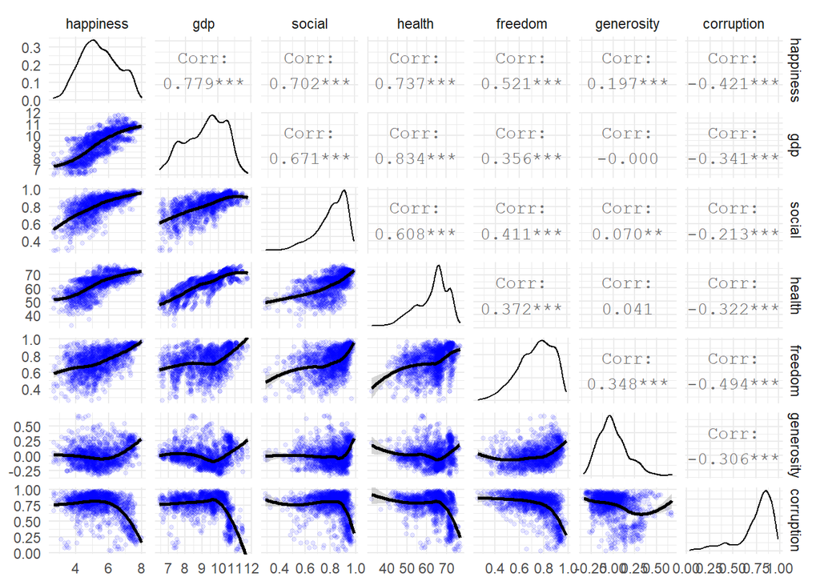

```r
ggpairs(dados_regressao %>%
          select(
              happiness,
              gdp,
              social,
              health,
              freedom,
              generosity,
              corruption

          )
        ,
        lower = list(continuous = wrap(ggally_smooth_loess, alpha = 0.1, size = 1, color = "blue"))

  ) +
  theme_minimal()
```

A função **lm()** possibilita a estimação de um modelo linear

```r
modelo <- lm(formula = happiness ~
             gdp +
             social +
             health +
             freedom +
             generosity +
             corruption,


   data = dados_regressao)
```

Podemos ver que os betas são significantes e o $R^2$, alto.

```r
summary(modelo)
```

```
##
## Call:
## lm(formula = happiness ~ gdp + social + health + freedom + generosity +
##     corruption, data = dados_regressao)
##
## Residuals:
##      Min       1Q   Median       3Q      Max
## -1.87609 -0.35849  0.01792  0.37772  1.92261
##
## Coefficients:
##              Estimate Std. Error t value Pr(>|t|)
## (Intercept) -1.878844   0.189128  -9.934  < 2e-16 ***
## gdp          0.327553   0.026567  12.329  < 2e-16 ***
## social       2.472711   0.176387  14.019  < 2e-16 ***
## health       0.031099   0.003701   8.403  < 2e-16 ***
## freedom      1.017861   0.132162   7.702 2.42e-14 ***
## generosity   0.683537   0.101401   6.741 2.23e-11 ***
## corruption  -0.550436   0.098312  -5.599 2.56e-08 ***
## ---
## Signif. codes:  0 '***' 0.001 '**' 0.01 '*' 0.05 '.' 0.1 ' ' 1
##
## Residual standard error: 0.5848 on 1509 degrees of freedom
##   (188 observations deleted due to missingness)
## Multiple R-squared:  0.7359, Adjusted R-squared:  0.7348
## F-statistic: 700.6 on 6 and 1509 DF,  p-value: < 2.2e-16
```

Entretanto cada variável explicativa está em uma unidade diferente, e muitas destas unidades não têm um significado intuitivo.

Isso dificulta a comparação dos $\beta$

### Exercício 7 - Normalizando dados

Vamos normalizar os dados usando o seguinte cálculo:

$$var\_norm_{i} = \frac{var_{i} - mediana(var)}{mad(var)}$$

onde mad é a [mediana dos desvios absolutos](https://en.wikipedia.org/wiki/Median_absolute_deviation).

Normalize os dados do tibble dado_regressao e crie um tibble chamado dados_regressao_normalizados.

- Para levar em conta o fato de que o mundo evolui ao longo dos anos, agrupe por ano
- Use a função **mutate()** e a função **across().** Use **where(is.numeric)** para selecionar as colunas que vem ser normalizadas
- Use a função **mad()** da biblioteca **stats**

```r
dados_regressao_normalizados <- dados_regressao %>%
  group_by(year) %>%
  mutate(
    across(
      .cols = where(is.numeric),
      .fns = ~(.x - median(.x, na.rm = TRUE))/mad(.x,na.rm = TRUE )
    )
  )
```

Com os dados normalizados, dá pra ter uma ideia melhor do impacto de cada variável

```r
modelo_normalizados <- lm(formula = happiness ~
             gdp +
             social +
             health +
             freedom +
             generosity +
             corruption,


   data = dados_regressao_normalizados)


summary(modelo_normalizados)
```

```
##
## Call:
## lm(formula = happiness ~ gdp + social + health + freedom + generosity +
##     corruption, data = dados_regressao_normalizados)
##
## Residuals:
##      Min       1Q   Median       3Q      Max
## -1.61111 -0.29543  0.00521  0.30025  1.82012
##
## Coefficients:
##             Estimate Std. Error t value Pr(>|t|)
## (Intercept)  0.20571    0.01465  14.041  < 2e-16 ***
## gdp          0.40085    0.02977  13.463  < 2e-16 ***
## social       0.21891    0.01672  13.089  < 2e-16 ***
## health       0.17593    0.02207   7.973 3.04e-15 ***
## freedom      0.15345    0.01704   9.003  < 2e-16 ***
## generosity   0.08692    0.01339   6.490 1.16e-10 ***
## corruption  -0.05681    0.01057  -5.376 8.80e-08 ***
## ---
## Signif. codes:  0 '***' 0.001 '**' 0.01 '*' 0.05 '.' 0.1 ' ' 1
##
## Residual standard error: 0.5031 on 1508 degrees of freedom
##   (189 observations deleted due to missingness)
## Multiple R-squared:  0.7347, Adjusted R-squared:  0.7336
## F-statistic: 695.9 on 6 and 1508 DF,  p-value: < 2.2e-16
```

### Exercício 8 - Rodando o modelo pra cada regiões

O código abaixo adiciona as regiões ao tibble normalizado

```r
dados_reg_continente <- dados_regressao_normalizados %>%
    left_join(
      regioes,
      by = c("country_name" = "country")
    )


glimpse(dados_reg_continente)
```

```
## Rows: 1,704
## Columns: 10
## Groups: year [14]
## $ country_name <chr> "Afghanistan", "Afghanistan", "Afghanistan", "Afghanis...
## $ year         <dbl> 2008, 2009, 2010, 2011, 2012, 2013, 2014, 2015, 2016, ...
## $ happiness    <dbl> -1.41184861, -0.82271573, -0.55681405, -1.30881840, -1...
## $ gdp          <dbl> -1.255445171, -1.385032482, -1.542369229, -1.388723831...
## $ social       <dbl> -3.01632884, -2.87766623, -3.61370050, -2.72957720, -2...
## $ health       <dbl> -1.315570637, -2.178112710, -2.084788663, -1.941439200...
## $ freedom      <dbl> 0.23894093, -0.16462880, -0.88528047, -1.63363297, -0....
## $ generosity   <dbl> 1.18991234, 1.59670874, 1.04180789, 1.49334939, 1.6664...
## $ corruption   <dbl> 0.47285808, 0.19682159, -0.77271091, -0.53285271, -0.2...
## $ region       <chr> "Southern Asia", "Southern Asia", "Southern Asia", "So...
```

Vamos, agora, rodar o modelo em cada região.

Para isso, precisamos:

- Aninhar todos os campos que não sejam região usando **nest()**
- Use a função **rowwise()** para determinar que as operações a partir daí serão feitas linha a linha.
- Criar um novo campo com o resultado da estimação do modelo, usando **mutate(),** e **lm().** Note que **map()** não é necessário, pois já foi determinado que as operações ocorrerão linha a linha.
- Criar um novo campo de nome coefs com os coeficientes extraídos do resultado do modelo, usando **mutate(),** **tidy()**
- Dê **ungroup()** pois as próximas operações podem ser feitas vetorialmente para o tibble inteiro
- Retire as colunas dados, modelo
- Dê **unnest()** em coefs
- Selecione somente os campos region, estimate, term

```r
dados_reg_continente_executado <- dados_reg_continente %>%
  nest(
    dados = -region
  ) %>%
  rowwise() %>%
  mutate(
    modelo = list(lm(
          formula = happiness ~
            gdp +
            social +
            health +
            freedom +
            generosity +
            corruption,
          data = dados
        )
    )
  ) %>%
  mutate(
    coefs = list(tidy(modelo))
  ) %>%
  ungroup() %>%
  select(
    -c(dados, modelo)
  ) %>%
  unnest(
    coefs
  ) %>%
  select(
    region,
    estimate,
    term
  )
```

```r
coefs <- dados_reg_continente_executado %>%
  pivot_wider(
    names_from = term,
    values_from = estimate
  ) %>%
  janitor::clean_names()


coefs %>%
  gt() %>%
  cols_label(
    region = "Região",
    intercept = "Índice com medianas",
    gdp = "PIB",
    social = "Social",
    health = "Anos de vida",
    freedom = "Liberdade",
    generosity = "Generosidade",
    corruption = "Corrupção"
  ) %>%
  fmt_number(
    columns = 2:8,
    dec_mark = ",",
    decimals = 2
  )
```

| Região | Índice com medianas | PIB | Social | Anos de vida | Liberdade | Generosidade | Corrupção |
| --- | --- | --- | --- | --- | --- | --- | --- |
| Southern Asia | −0,50 | 0,31 | −0,03 | −0,05 | −0,02 | 0,03 | −0,29 |
| Central and Eastern Europe | 0,08 | 0,30 | 0,25 | 0,00 | 0,17 | 0,07 | 0,02 |
| Middle East and Northern Africa | 0,24 | 0,43 | 0,27 | 0,57 | 0,21 | −0,06 | 0,06 |
| Sub-Saharan Africa | −0,53 | 0,29 | 0,13 | −0,06 | 0,07 | 0,15 | 0,04 |
| Latin America and Caribbean | 0,57 | 0,67 | 0,14 | 0,09 | 0,19 | 0,08 | −0,10 |
| Australia and New Zealand | −1,48 | 1,43 | 0,38 | −0,19 | 0,26 | 0,38 | −0,18 |
| Western Europe | −0,13 | 0,45 | 0,31 | 0,41 | 0,16 | 0,07 | −0,11 |
| Southeastern Asia | 0,26 | 0,49 | 0,37 | 0,19 | −0,03 | −0,00 | 0,04 |
| North America | 0,21 | 0,32 | 0,61 | 0,20 | 0,31 | 0,15 | 0,05 |
| Eastern Asia | −0,38 | 0,90 | 0,08 | 0,35 | 0,10 | 0,34 | 0,08 |
| NA | 0,33 | 0,71 | 0,16 | −0,22 | 0,19 | 0,20 | 0,32 |

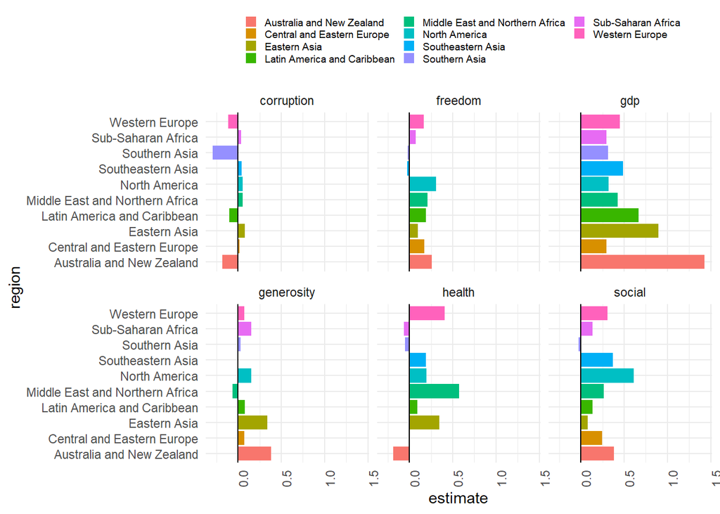

```r
ggplot(
  dados_reg_continente_executado %>%
    filter(
      term != "(Intercept)",
      !is.na(region)
    )
  ) +
  geom_col(
    aes(
      y = estimate,
      x = region,
      fill = region
    )
  ) +
  geom_hline(
    color = "black",
    yintercept = 0
  ) +
  coord_flip() +
  labs(
    fill = ""
  ) +
  facet_wrap(~term) +
  theme_minimal() +
  theme(
    axis.text.x = element_text(angle = 90),
    legend.position = "top",
    legend.text = element_text(size = 7),
    legend.key.size = unit(.3, "cm")
  ) +
  guides(
    fill = guide_legend(
      nrow = 4
    )
  )
```